# STOR 455 Homework 2

```r
library(readr)
library(mosaic)
library(Stat2Data)
library(car)
library(dplyr)
```

```r
DistanceHome = read_csv("/Users/reidbrown/Documents/Senior/Spring 2020/STOR 455/Class Example Data/DistanceHome.csv")
Domestic = subset(DistanceHome, Distance <250)
```

```r
UsedCars = read_csv("/Users/reidbrown/Documents/Senior/Spring 2020/STOR 455/Class Example Data/UsedCars.csv")
head(UsedCars)
```

| Id | Price | Year | Mileage | City | State | Vin | Make | Model |
| --- | --- | --- | --- | --- | --- | --- | --- | --- |
| 1 | 16472 | 2015 | 18681 | Jefferson City | MO | KL4CJBSBXFB267643 | Buick | EncoreConvenience |
| 2 | 15749 | 2015 | 27592 | Highland | IN | KL4CJASB5FB245057 | Buick | EncoreFWD |
| 3 | 16998 | 2015 | 13650 | Boone | NC | KL4CJCSB0FB264921 | Buick | EncoreLeather |
| 4 | 15777 | 2015 | 25195 | New Orleans | LA | KL4CJASB4FB217542 | Buick | EncoreFWD |
| 5 | 16784 | 2015 | 22800 | Las Vegas | NV | KL4CJBSB3FB166881 | Buick | EncoreConvenience |
| 6 | 17020 | 2016 | 16877 | Grand Island | NY | KL4CJASB7GB536760 | Buick | EncoreFWD |

```r
#make freq. table of all the models in the UsedCars dataset
cars = as.data.frame(table(UsedCars$Model))
head(cars)
```

|  | Var1 | Freq |
| --- | --- | --- |
| 1 | 1 | 437 |
| 2 | 124 | 56 |
| 3 | 1500 | 1 |
| 4 | 15002WD | 296 |
| 5 | 15004WD | 647 |
| 6 | 1500Big | 749 |

```r
#renaming columns
names(cars)[1] = "Model"
names(cars)[2] = "Count"
head(cars)
```

|  | Model | Count |
| --- | --- | --- |
| 1 | 1 | 437 |
| 2 | 124 | 56 |
| 3 | 1500 | 1 |
| 4 | 15002WD | 296 |
| 5 | 15004WD | 647 |
| 6 | 1500Big | 749 |

```r
cars2 = subset(cars, Count>=2500)
cars2
```

|  | Model | Count |
| --- | --- | --- |
| 29 | 200Limited | 4299 |
| 45 | 3 | 11131 |
| 103 | 5 | 5348 |
| 217 | AcadiaAWD | 3511 |
| 218 | AcadiaFWD | 4080 |
| 230 | Accord | 14946 |
| 249 | Altima2.5 | 15735 |
| 253 | Altima4dr | 2950 |
| 367 | C-ClassC300 | 3307 |
| 412 | CamaroCoupe | 5729 |

[output cut: 76 more lines]

Don’t choose CamrySE

```r
set.seed(11111)
MyCars = sample_n(subset(UsedCars, Model =="Accord"), 200)
range(MyCars$Year)
```

```
## [1] 2002 2017
```

```r
MyCars$Age = 2017 - MyCars$Year
#head(MyCars)
```

**MODEL #1**

*Model 1, number 1*

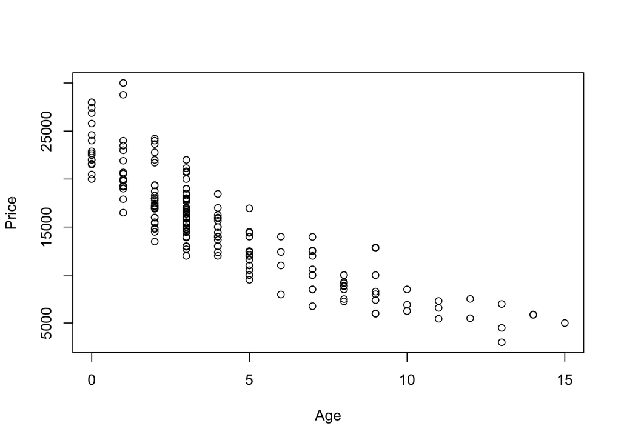

```r
plot(Price~Age, data=MyCars)
```

```r
model1.1 = lm(Price~Age, data=MyCars)
summary(model1.1)
```

```
##
## Call:
## lm(formula = Price ~ Age, data = MyCars)
##
## Residuals:
##     Min      1Q  Median      3Q     Max
## -4932.1 -1612.7  -431.3  1230.2 10243.3
##
## Coefficients:
##             Estimate Std. Error t value Pr(>|t|)
## (Intercept) 21171.94     300.61   70.43   <2e-16 ***
## Age         -1415.28      59.01  -23.99   <2e-16 ***
## ---
## Signif. codes:  0 '***' 0.001 '**' 0.01 '*' 0.05 '.' 0.1 ' ' 1
##
## Residual standard error: 2659 on 198 degrees of freedom
## Multiple R-squared:  0.744,  Adjusted R-squared:  0.7427
## F-statistic: 575.3 on 1 and 198 DF,  p-value: < 2.2e-16
```

According to the summary of model1.1, the slope coefficient is -1415.28. This means that as a car’s age increased by 1 it’s price will decrease by $1415.28. This makes sense because we know that cars are depreciating assets and that an older car is less valuable than a newer car with other variables held constant.

*Model 1, number 2*

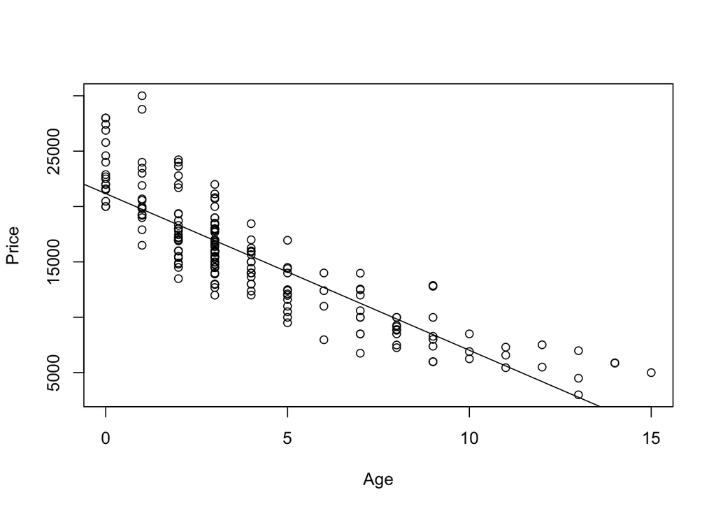

```r
plot(Price~Age, data=MyCars)
model1.1 = lm(Price~Age, data=MyCars)
abline(model1.1)
```

*Model 1, number 3*

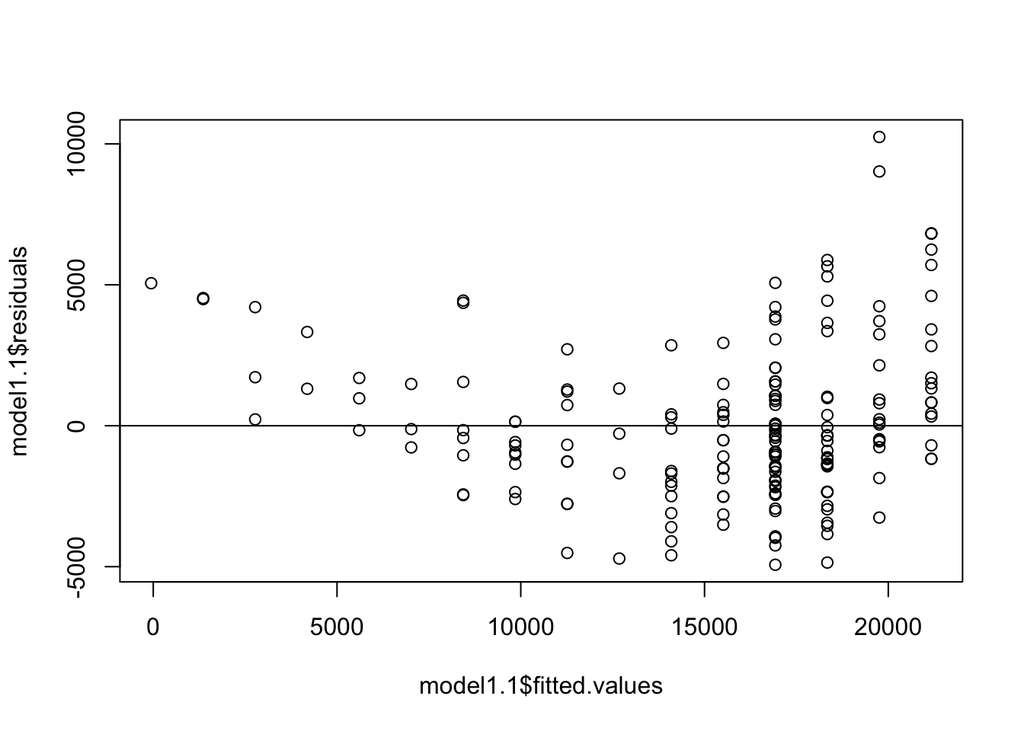

```r
plot(model1.1$residuals~model1.1$fitted.values)
abline(a=0, b=0)
```

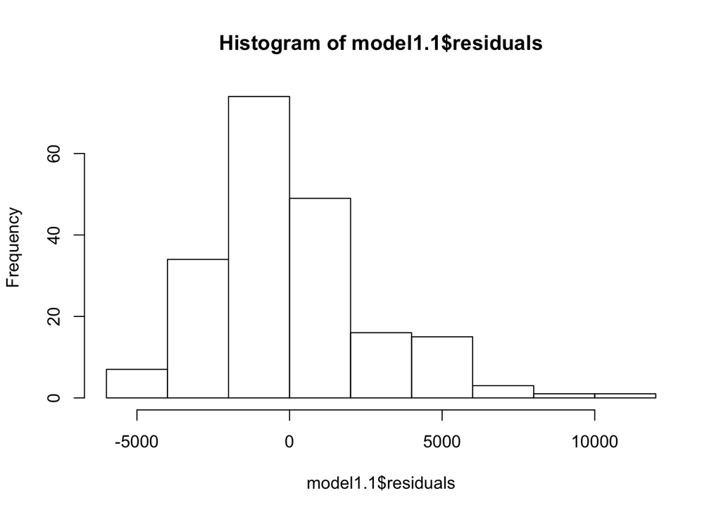

```r
hist(model1.1$residuals)
```

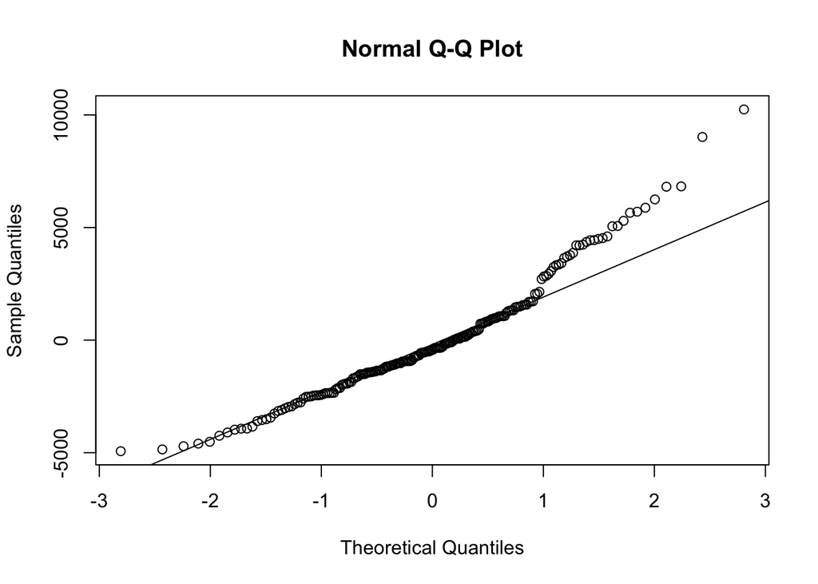

```r
qqnorm(model1.1$residuals)
qqline(model1.1$residuals)
```

This distribution does not appear to meet the conditions for linearity. The residuals flare out towards the right side of the plot. The histogram appears to be right-skewed instead of normally distributed. The QQ Plot does not show true independence, like the histogram, the residuals tend to be right-skewed.

*Model 1, number 4*

```r
max(model1.1$residuals)
```

```
## [1] 10243.33
```

```r
#min(model1.1$residuals)
which.max(model1.1$residuals)
```

```
## 93
## 93
```

```r
MyCars[93,]
```

| Id | Price | Year | Mileage | City | State | Vin | Make | Model | Age |
| --- | --- | --- | --- | --- | --- | --- | --- | --- | --- |
| 781823 | 30000 | 2016 | 103 | OKARCHE | OK | 1HGCT2B08GA002534 | Honda | Accord | 1 |

```r
rstandard(model1.1)[93]
```

```
##       93
## 3.870347
```

```r
rstudent(model1.1)[93]
```

```
##       93
## 4.015441
```

*Model 1, number 5*

```r
2*(2/200) #threshold value for moderate leverage
```

```
## [1] 0.02
```

```r
3*(2/200) #threshold value for high leverage
```

```
## [1] 0.03
```

```r
head(sort(hatvalues(model1.1),decreasing=TRUE),n=1)
```

```
##         78
## 0.06485136
```

```r
MyCars$Leverage = hatvalues(model1.1)
MyCars[c(93),]
```

| Id | Price | Year | Mileage | City | State | Vin | Make | Model | Age | Leverage |
| --- | --- | --- | --- | --- | --- | --- | --- | --- | --- | --- |
| 781823 | 30000 | 2016 | 103 | OKARCHE | OK | 1HGCT2B08GA002534 | Honda | Accord | 1 | 0.009358035 |

The leverage value for the car with the largest residual (row 93 in my dataset) was 0.009358035. This value didn’t surpass the threshold values for moderate and high leverage so we can’t say this point has high leverage based on this test. This point isn’t likely to have a large affect on our linear model’s fit.

*Model 1, number 6*

```r
confint(model1.1,level =0.90)
```

```
##                   5 %      95 %
## (Intercept) 20675.160 21668.725
## Age         -1512.788 -1317.765
```

The above code gives a 90% confidence interval for both the intercept and the slope, called “Age” in this case. This tells us that we are 90% sure that the true slope that explains the relationship between Price and Age is between -1512.788 and -1317.765.

*Model 1, number 7*

```r
#ask about hypothesis for each test
#Use cor.test(), anova(), and summary()
summary(model1.1)
```

```
##
## Call:
## lm(formula = Price ~ Age, data = MyCars)
##
## Residuals:
##     Min      1Q  Median      3Q     Max
## -4932.1 -1612.7  -431.3  1230.2 10243.3
##
## Coefficients:
##             Estimate Std. Error t value Pr(>|t|)
## (Intercept) 21171.94     300.61   70.43   <2e-16 ***
## Age         -1415.28      59.01  -23.99   <2e-16 ***
## ---
## Signif. codes:  0 '***' 0.001 '**' 0.01 '*' 0.05 '.' 0.1 ' ' 1
##
## Residual standard error: 2659 on 198 degrees of freedom
## Multiple R-squared:  0.744,  Adjusted R-squared:  0.7427
## F-statistic: 575.3 on 1 and 198 DF,  p-value: < 2.2e-16
```

```r
anova(model1.1)
```

|  | Df | Sum Sq | Mean Sq | F value | Pr(>F) |
| --- | --- | --- | --- | --- | --- |
| Age | 1 | 4067855845 | 4067855845 | 575.3067 | 1.736072e-60 |
| Residuals | 198 | 1400010485 | 7070760 | NA | NA |

```r
cor.test(MyCars$Price, MyCars$Age)
```

```
##
##  Pearson's product-moment correlation
##
## data:  x and y
## t = -23.986, df = 198, p-value < 2.2e-16
## alternative hypothesis: true correlation is not equal to 0
## 95 percent confidence interval:
##  -0.8942562 -0.8221766
## sample estimates:
##        cor
## -0.8625293
```

*T-Test:* Null Hypothesis: H<sub>0</sub>: β<sub>Age</sub>=0

Alternative Hypothesis: H<sub>a</sub>: β<sub>Age</sub>≠0

*ANOVA:* Null Hypothesis: H<sub>0</sub>: β<sub>Age</sub>=0

Alternative Hypothesis: H<sub>a</sub>: β<sub>Age</sub>≠0

*Correlation Test:* Null Hypothesis: H<sub>0</sub>: β<sub>Age</sub>=0

Alternative Hypothesis: H<sub>a</sub>: β<sub>Age</sub>≠0

All three of the tests return a p-value of 2.2e-16 which is effectively 0. Since this is a single linear regression model, the ANOVA test and the T-Test tell us the same thing. Both of these tests returned a low p-value so we can say that Age has a significant effect on a car’s Price. The Correlation Test also returned a p-value of essentially 0. This means that there is a signifcant relationship between the two variables. Also, the correlation value is -0.8625293 which shows that the relationship is strong and negative.

*Model 1, number 8*

```r
newx = data.frame(Age=3)
predict.lm(model1.1, newx, interval = "confidence", level=0.90)
```

```
##        fit      lwr      upr
## 1 16926.11 16601.17 17251.06
```

```r
predict.lm(model1.1, newx, interval = "prediction", level=0.90)
```

```
##        fit      lwr      upr
## 1 16926.11 12519.74 21332.49
```

The top row is refering to a confidence interval and the bottom row is refering to a prediction interval. The confidence interval is saying that the average value for all three year old Honda Accords will be between $16601.17 and 17251.06 USD 90% of the time. The prediction interval is saying that we expect a unique, three year old Honda Accord to cost between 12519.74 and 21332.49 USD. The prediction interval is wider than the confidence interval because there is an extra 1 added to the denominator term in the calculation. This extra 1 is necessary in the prediction interval becuase it is harder to predict one value as opposed to an entire population’s average value.

*Model 1, number 9*

```r
summary(model1.1)
```

```
##
## Call:
## lm(formula = Price ~ Age, data = MyCars)
##
## Residuals:
##     Min      1Q  Median      3Q     Max
## -4932.1 -1612.7  -431.3  1230.2 10243.3
##
## Coefficients:
##             Estimate Std. Error t value Pr(>|t|)
## (Intercept) 21171.94     300.61   70.43   <2e-16 ***
## Age         -1415.28      59.01  -23.99   <2e-16 ***
## ---
## Signif. codes:  0 '***' 0.001 '**' 0.01 '*' 0.05 '.' 0.1 ' ' 1
##
## Residual standard error: 2659 on 198 degrees of freedom
## Multiple R-squared:  0.744,  Adjusted R-squared:  0.7427
## F-statistic: 575.3 on 1 and 198 DF,  p-value: < 2.2e-16
```

Our Linear Model: y(predicted) = 21171.94 - (1415.28 * Age)

Solve for when y(predicted) = 0

0 = 21171.94 - (1415.28 * Age)

-21171.94 = -(1415.28 * Age)

Age = -21171.94 / -1415.28

```r
FreeCarAge = -21171.94 / -1415.28
FreeCarAge
```

```
## [1] 14.95954
```

According to our model, a car should be free once the car is approximately 15 years old (14.95954 years old). In the real world, cars do get cheaper as they get older but they should never be free. Our model fits the data well for the ages we have available to us.

```r
max(MyCars$Age)
```

```
## [1] 15
```

```r
which.max(MyCars$Age)
```

```
## [1] 78
```

```r
MyCars[78,]
```

| Id | Price | Year | Mileage | City | State | Vin | Make | Model | Age | Leverage |
| --- | --- | --- | --- | --- | --- | --- | --- | --- | --- | --- |
| 371182 | 4999 | 2002 | 107950 | West Palm Beach | FL | 1HGCG56662A024402 | Honda | Accord | 15 | 0.06485136 |

As it turns out, the oldest car in our data set is 15 years old and it costs 4,999 USD. It is likely that this relationship is probably non-linear as we model higher age values. A linear model works well for a narrow age range, but a non-linear model may fit better.

*Model 1, number 10*

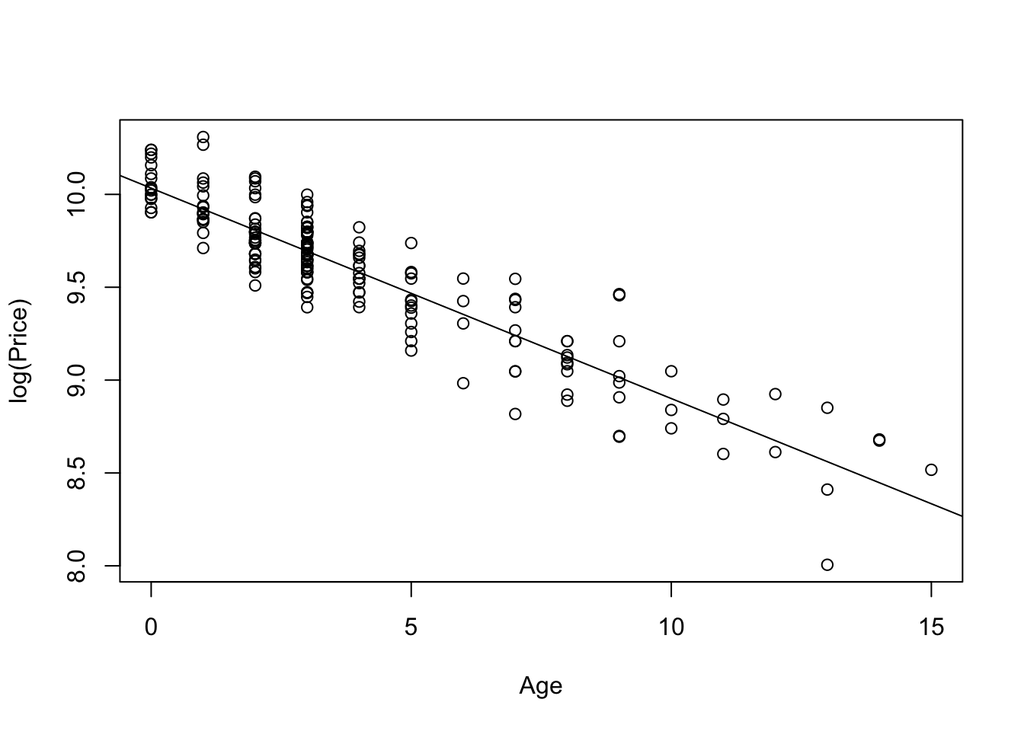

```r
plot(log(Price)~Age, data=MyCars)
model1.2<-lm(log(Price)~Age, data=MyCars)
abline(model1.2)
```

[figure not shown]

```r
plot((Price**2)~Age, data=MyCars, ylim=c(0,100))
model1.5=lm((Price**2)~Age, data=MyCars)
abline(model1.5)
```

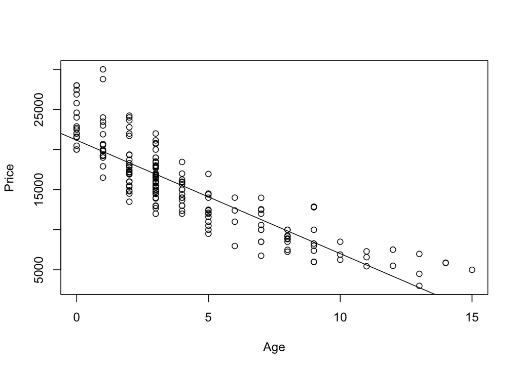

```r
plot(Price~(Age**2), data=MyCars)
model1.6=lm(Price~(Age**2), data=MyCars)
abline(model1.6)
```

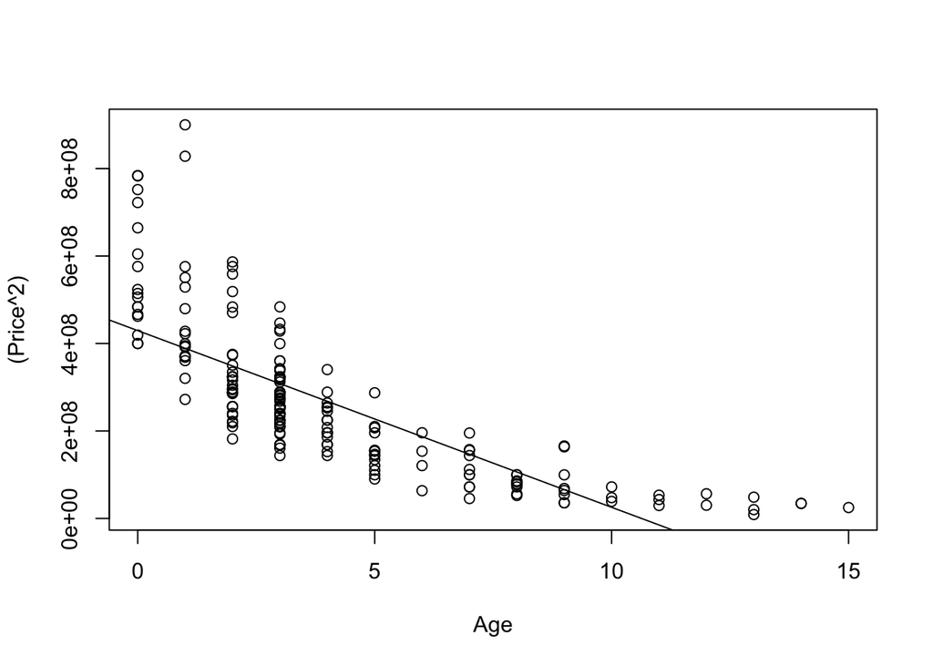

```r
plot((Price**2)~(Age**2), data=MyCars)
model1.7=lm((Price**2)~(Age**2), data=MyCars)
abline(model1.7)
```

Looking at all of the models, it appears that the model that predicts log(Pirce)~Age shows the most tight relationship around the linear regression line. Below are further plots to examine this relationship’s linear model conditions.

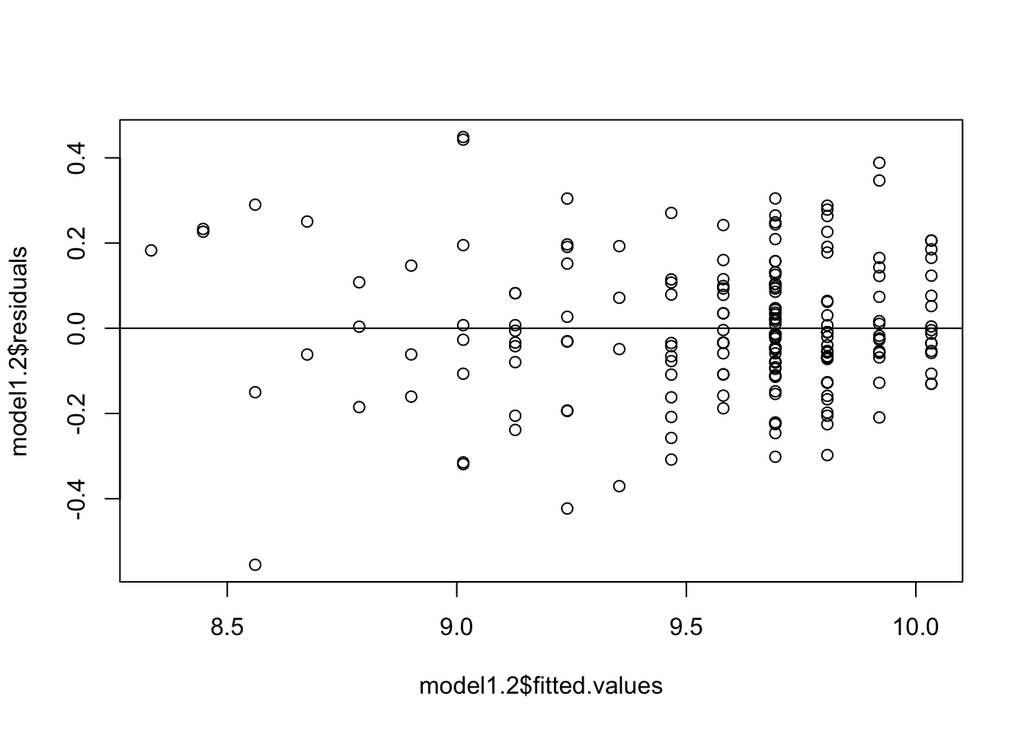

```r
plot(model1.2$residuals~model1.2$fitted.values)
abline(a=0, b=0)
```

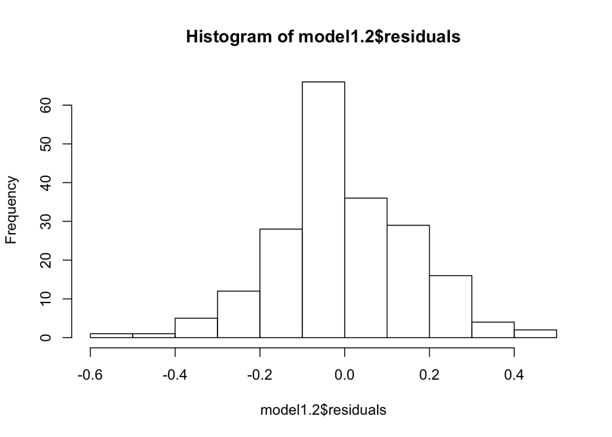

```r
hist(model1.2$residuals)
```

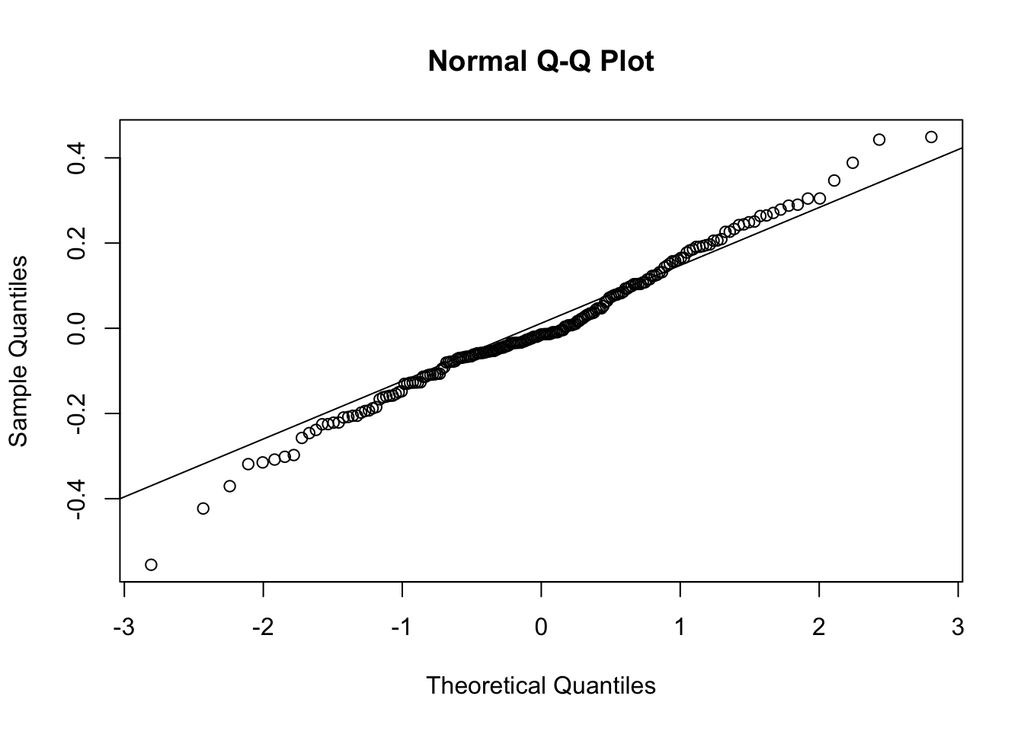

```r
qqnorm(model1.2$residuals)
qqline(model1.2$residuals)
```

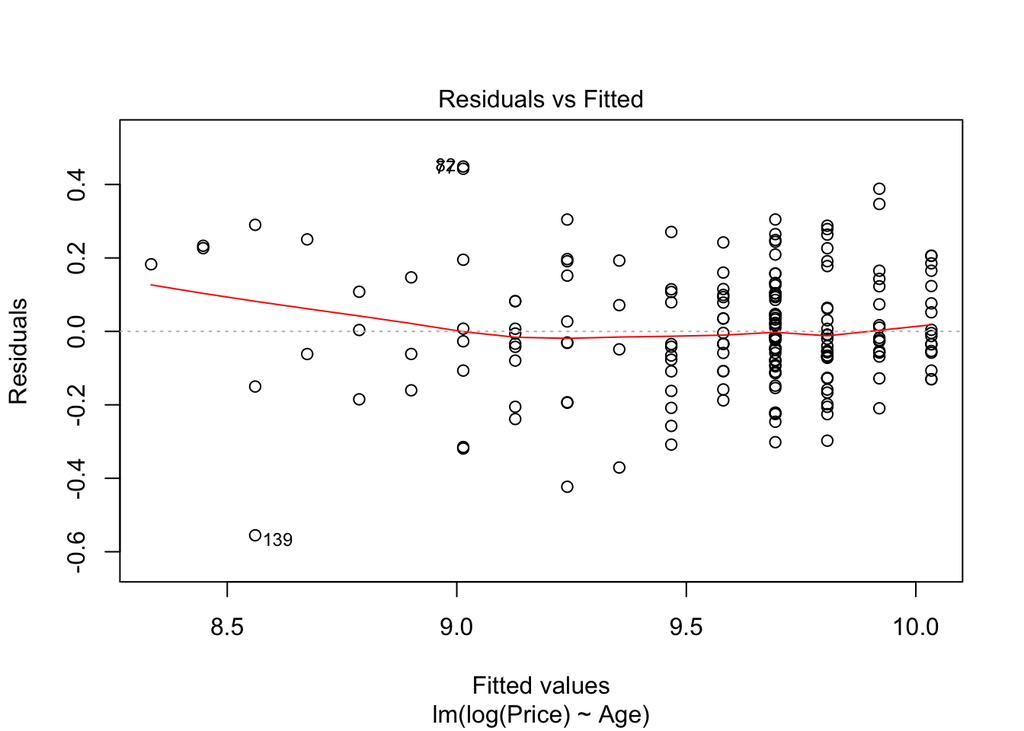

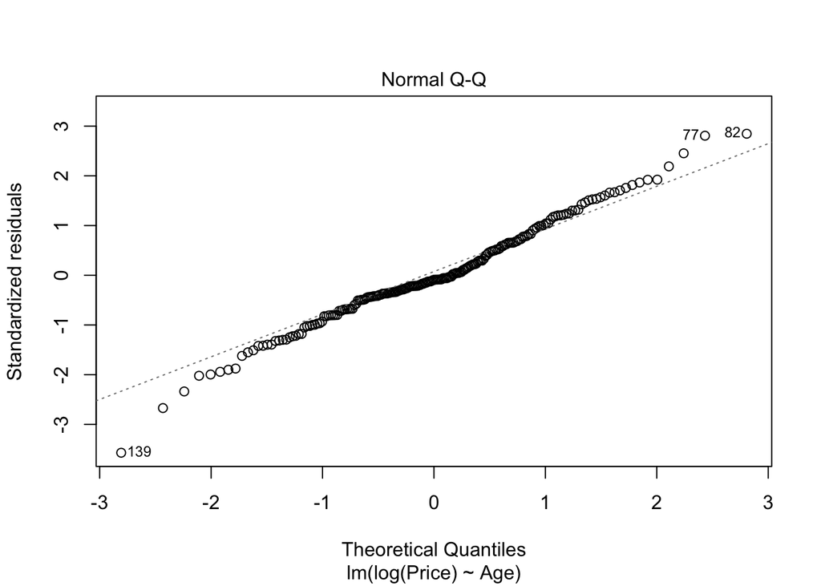

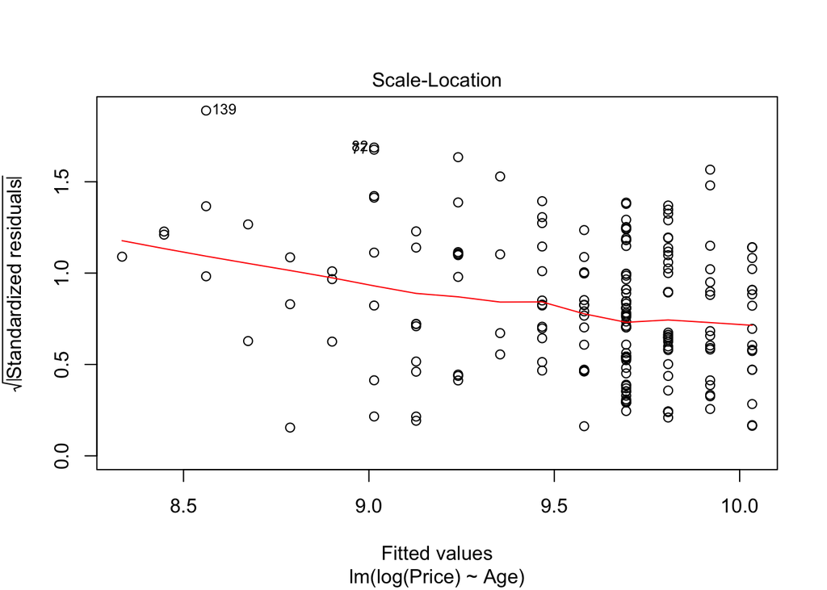

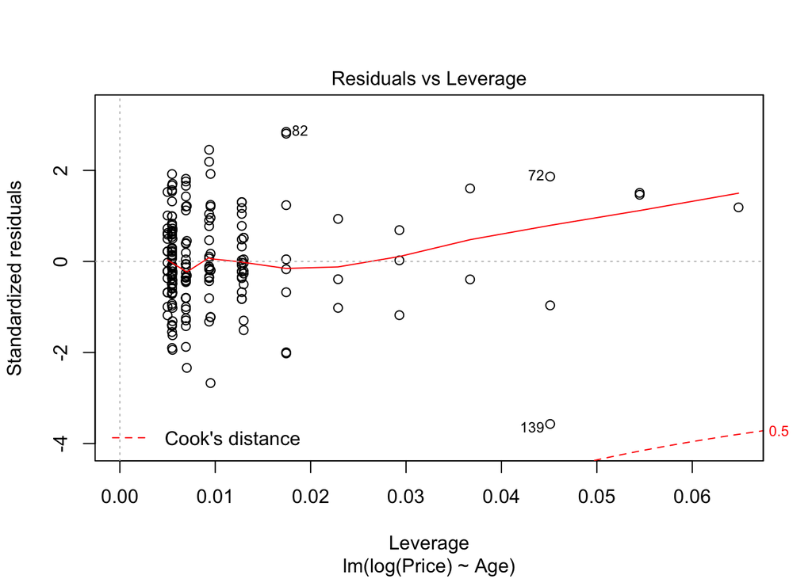

```r
plot(model1.2)
```

Based on the residual vs fitted plot we see that the resiudals seem to have random distrubution around the horizontal reference line. While the zero mean condition isn’t perfectly met in the residuals, they only deviate from this pattern a little bit for the smallest fitted values. The QQ norm plots show that our data generally follows the linear reference line. This implies indepence between the two variables. The histogram shows us that there is right side skew towards larger residuals but they still appear to be centered at zero and appear to be somewhat normally distributed. All things considered, this model appears to meet the conditions for linear modeling. TThis model has less variance in its qqplot, and its residual vs fitted value plot has a mean closer to zero than our original model. We should use this model to predict the relationship between Price and Age.

**MODEL 2**

*Model 2, number 1*

```r
model2.1 = lm(Price~Age+Mileage, data = MyCars)
summary(model2.1)
```

```
##
## Call:
## lm(formula = Price ~ Age + Mileage, data = MyCars)
##
## Residuals:
##     Min      1Q  Median      3Q     Max
## -5255.0 -1626.6  -342.3  1408.2  9321.8
##
## Coefficients:
##               Estimate Std. Error t value Pr(>|t|)
## (Intercept)  2.164e+04  2.934e+02  73.738  < 2e-16 ***
## Age         -9.552e+02  1.006e+02  -9.497  < 2e-16 ***
## Mileage     -4.365e-02  7.981e-03  -5.469 1.36e-07 ***
## ---
## Signif. codes:  0 '***' 0.001 '**' 0.01 '*' 0.05 '.' 0.1 ' ' 1
##
## Residual standard error: 2484 on 197 degrees of freedom
## Multiple R-squared:  0.7777, Adjusted R-squared:  0.7755
## F-statistic: 344.6 on 2 and 197 DF,  p-value: < 2.2e-16
```

```r
anova(model2.1)
```

|  | Df | Sum Sq | Mean Sq | F value | Pr(>F) |
| --- | --- | --- | --- | --- | --- |
| Age | 1 | 4067855845 | 4067855845 | 659.31712 | 8.926655e-65 |
| Mileage | 1 | 184559565 | 184559565 | 29.91337 | 1.359898e-07 |
| Residuals | 197 | 1215450920 | 6169802 | NA | NA |

*Model 2, number 2*

```r
max(model2.1$residuals)
```

```
## [1] 9321.795
```

```r
#min(model1.1$residuals)
which.max(model2.1$residuals)
```

```
## 93
## 93
```

```r
MyCars[93,]
```

| Id | Price | Year | Mileage | City | State | Vin | Make | Model | Age | Leverage |
| --- | --- | --- | --- | --- | --- | --- | --- | --- | --- | --- |
| 781823 | 30000 | 2016 | 103 | OKARCHE | OK | 1HGCT2B08GA002534 | Honda | Accord | 1 | 0.009358035 |

Largest residual is 9321.795.

*Model 2, number 3*

```r
#Confused about this one NOT DONE
data("MyCars")
cor.test(MyCars$Price, MyCars$Age)
```

```
##
##  Pearson's product-moment correlation
##
## data:  x and y
## t = -23.986, df = 198, p-value < 2.2e-16
## alternative hypothesis: true correlation is not equal to 0
## 95 percent confidence interval:
##  -0.8942562 -0.8221766
## sample estimates:
##        cor
## -0.8625293
```

```r
cor.test(MyCars$Price, MyCars$Mileage)
```

```
##
##  Pearson's product-moment correlation
##
## data:  x and y
## t = -20.322, df = 198, p-value < 2.2e-16
## alternative hypothesis: true correlation is not equal to 0
## 95 percent confidence interval:
##  -0.8625075 -0.7713982
## sample estimates:
##        cor
## -0.8221491
```

```r
cor.test(MyCars$Age, MyCars$Mileage)
```

```
##
##  Pearson's product-moment correlation
##
## data:  x and y
## t = 21.476, df = 198, p-value < 2.2e-16
## alternative hypothesis: true correlation is not equal to 0
## 95 percent confidence interval:
##  0.7893067 0.8737871
## sample estimates:
##       cor
## 0.8364488
```

```r
summary(model2.1)
```

```
##
## Call:
## lm(formula = Price ~ Age + Mileage, data = MyCars)
##
## Residuals:
##     Min      1Q  Median      3Q     Max
## -5255.0 -1626.6  -342.3  1408.2  9321.8
##
## Coefficients:
##               Estimate Std. Error t value Pr(>|t|)
## (Intercept)  2.164e+04  2.934e+02  73.738  < 2e-16 ***
## Age         -9.552e+02  1.006e+02  -9.497  < 2e-16 ***
## Mileage     -4.365e-02  7.981e-03  -5.469 1.36e-07 ***
## ---
## Signif. codes:  0 '***' 0.001 '**' 0.01 '*' 0.05 '.' 0.1 ' ' 1
##
## Residual standard error: 2484 on 197 degrees of freedom
## Multiple R-squared:  0.7777, Adjusted R-squared:  0.7755
## F-statistic: 344.6 on 2 and 197 DF,  p-value: < 2.2e-16
```

*Age:* Null Hypothesis: H<sub>0</sub>: β<sub>Age</sub>=0

Alternative Hypothesis: H<sub>a</sub>: β<sub>Age</sub>≠0

*Mileage:* Null Hypothesis: H<sub>0</sub>: β<sub>Mileage</sub>=0

Alternative Hypothesis: H<sub>a</sub>: β<sub>Mileage</sub>≠0

Looking at the p values for Age ( p < 2e-16) and Mileage (p = 1.36e-07) we can reject the null hypotheses. Because of the low p-values (p < 0.05) we can conclude that both the variables are important in this model. Becasue Mileage has a larger p-value than Age, Mileage is a less important variable than Age in this model.

*Model 2, number 4*

```r
source("/Users/reidbrown/Documents/Senior/Spring 2020/STOR 455/Class Scripts/anova455.R")
```

[output not shown]

Null Hypothesis: H<sub>0</sub>: β<sub>Age</sub> + β<sub>Mileage</sub>=0

Alternative Hypothesis: H<sub>a</sub>: β<sub>Age</sub> + β<sub>Mileage</sub>≠0

Based on our ANOVA test for our multiple regression model, the resulting p value is 2.2e-16 which is effectively 0. This means that it is significantly unlikely that the predicted price occured due to chance. Because of this, we reject the null hypothesis that Age and Mileage have no predicting power for a car’s Price.

*Model 2, number 5*

```r
vif(model2.1)
```

```
##      Age  Mileage
## 3.329412 3.329412
```

After calculating the VIF values for Age and Mileage, we can see that there is moderate multicollinearity between the two predictor variables. Because the value is not above 5, we can still assume this model is appropriate but it is possible that a model with only one of these predictor variables would work well too. We could look at adjusted R^2 to determine this.

*Model 2, number 6*

```r
multi_newx = data.frame(Age=3, Mileage=31000)
predict.lm(model2.1, multi_newx, interval = "confidence", level=0.90)
```

```
##        fit      lwr      upr
## 1 17419.24 17081.09 17757.39
```

```r
predict.lm(model2.1, multi_newx, interval = "prediction", level=0.90)
```

```
##        fit      lwr      upr
## 1 17419.24 13300.37 21538.11
```

The top row is refering to a confidence interval and the bottom row is refering to a prediction interval. The confidence interval is saying that the average value for all three year old Honda Accords with 31,000 miles will be between 17081.09 and 17757.39 USD 90% of the time. The prediction interval is saying that we expect a unique, three year old Honda Accord with 31,000 miles to cost between 13300.37 and 21538.11 USD. The prediction interval is wider than the confidence interval because there is an extra 1 added to the denominator term in the calculation. This extra 1 is necessary in the prediction interval becuase it is harder to predict one value as opposed to an entire population’s average value.